### **DOCHER Mathieu - IDU4**

# DATA731 - TP2 - Analyse et synthèse par modèle AR

## Partie I :

**Modélisation AR** = Auto Regressive Model (modèle dans lequel la série est expliquée par ses valeurs passées plutôt que par d'autres variables)

```python
import random as aleas  # pour generer des nombres aleatoires et +
import matplotlib.pyplot as plt # pour les graphiques
from scipy.signal import freqz   # pour avoir le TF de l'autocorrelation
import numpy as np #pour gerer les moyennes + covariances +++

n=1536 #  nombre de donnees a genener

#% Sequences des parametres des 3 modeles AR du second ordre
a=[
    [1,-0.1344,0.9025], # coefficients du premier processus AR
    [1,-1.6674,0.9025], # Ccoefficients du second processus AR
    [1, 1.7820,0.8100]  # coefficients du troisieme processus AR
]
```

**Génération d'une série temporelle (non-stationnaire globalement) composée de 3 blocs stationnaires :**

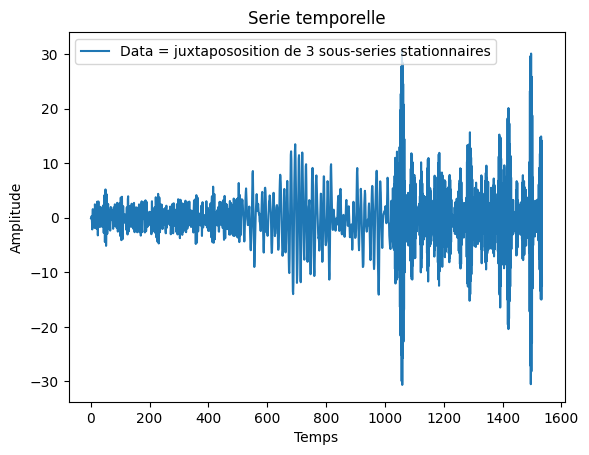

```python
# Génération et juxtaposition des 3 blocs de largeur n/3 chacun
t=range(-2,n-1)
y=[k*0 for k in t]
for k in range(1,int(n/3)):
    y[k+1]=-a[0][1]*y[k]-a[0][2]*y[k-1]+aleas.gauss(0,1)
for k in range(int(n/3)+1,2*int(n/3)):
    y[k+1]=-a[1][1]*y[k]-a[1][2]*y[k-1]+aleas.gauss(0,1)
for k in range(2*int(n/3)+1,n):
    y[k+1]=-a[2][1]*y[k]-a[2][2]*y[k-1]+aleas.gauss(0,1)
y=y[3:]  # suppression des donnees transitoires
t=t[3:]
# Trace- de la serie
plt.plot(t,y,label='Data = juxtapososition de 3 sous-series stationnaires')
plt.xlabel('Temps')
plt.ylabel('Amplitude')
plt.legend()
plt.title('Serie temporelle')
plt.show()
```

**Calcul et traces des spectres des trois sous-series à partir de freqz :**

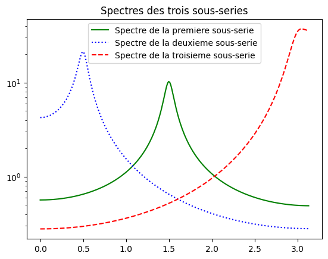

```python
# Puisqu'on connait les coeffs, le calcul se fait directement à partir des coeffs (ne dépend pas du nombre d'échantillons)
def spectre(*args):
	Np = 256 # nombre de points du spectre
	f=freqz(1,args[0],Np)[0] # recuperer les echantillons de frequences (abscisses)
	mag=[]   # hauteurs des frequences observables correspondantes (ordonnees)
	for arg in args:
		mag.append(abs(freqz(1,arg,Np)[1])) # calcul du spectre de chaque sous-serie
	return (f,mag)

f,mag=spectre(a[0],a[1],a[2])
## Calcul des spectres des trois sous-series
plt.semilogy(f,np.abs(mag[0]),'-g',label='Spectre de la premiere sous-serie')
mag11 = np.abs(mag[0]) # pour la suite
plt.semilogy(f,np.abs(mag[1]),':b',label='Spectre de la deuxieme sous-serie')
mag12 = np.abs(mag[1]) # pour la suite
plt.semilogy(f,np.abs(mag[2]),'--r',label='Spectre de la troisieme sous-serie')
mag13 = np.abs(mag[2]) # pour la suite
plt.legend()
## Traces des spectres des trois sous-series
plt.title('Spectres des trois sous-series')
plt.show()
```

**On choisit de décrire `Y` par un modèle AR d'ordre 3 (puis 4) et estimer les coefficients de ce modèle (réutiliser la partie déjà codée pour superposer les estimations locales de spectres avec le résultat esconté) :**

```
Coefficients du modèle AR(3) :  [-0.08082868 -0.63994712  0.3391578 ]
Coefficients du modèle AR(4) :  [ 0.02639557 -0.84226547  0.31360393  0.31614856]
```

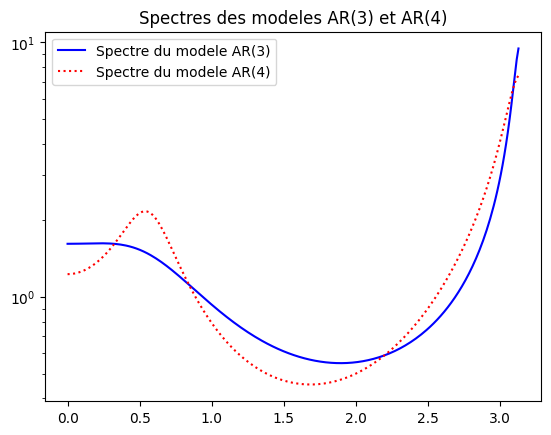

```python
# Calcul global sur n données
# Calcul des coefficients des modèles AR d'ordre 3 (et 4)
# On crée les versions translattées de y (y1,y2,y3,y4 et y5) (style autocorrelation)
y1 = y
y2 = np.roll(y, 1) # y2 est y décalé de 1 vers la droite
y3 = np.roll(y, 2)
y4 = np.roll(y, 3)
y5 = np.roll(y, 4)
A = [y1, y2, y3, y4, y5]

# Calcul de la matrice de covariance / d'autocorrélation 5*5
D = np.zeros((5,5))
for i in range(5):
    for j in range(5):
        D[i][j] = np.cov(A[i],A[j])[0][1]

# Calcul des coefficients par Yule-Walker
H = - np.linalg.inv(D[0:3,0:3]) @ D[0,1:4] # Ordre 3 (@ = produit matriciel)
E = - np.linalg.inv(D[0:4,0:4]) @ D[0,1:5] # Ordre 4

print("Coefficients du modèle AR(3) : ", H)
print("Coefficients du modèle AR(4) : ", E)

# Vecteurs de coefficients incluant a0=1 pour les ordres 3 et 4
H1 = [1,*H] # *H = moyen de déplier le tableau (si H = [2,3,4] alors H1 = [1,*H] = [1,2,3,4])
E1 = [1,*E]

# Trace des spectres estimés
Np = 256
f,mag = spectre(H1,E1)

plt.semilogy(f,np.abs(mag[0]),'-b',label='Spectre du modele AR(3)')
plt.semilogy(f,np.abs(mag[1]),':r',label='Spectre du modele AR(4)')

plt.legend()
plt.title('Spectres des modeles AR(3) et AR(4)')
plt.show()
```

**Calculs locaux sur m1 données avec m1 données avec m1 << n :**

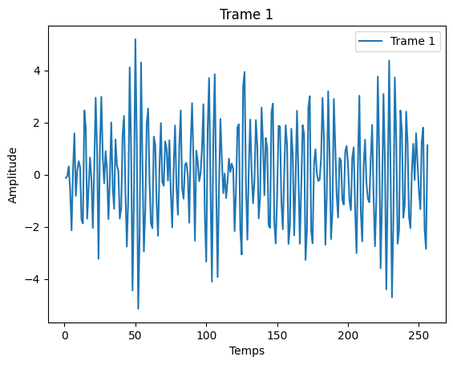

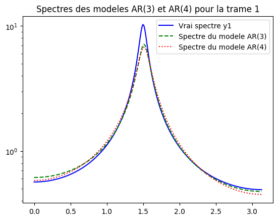

```python
m1 = 256 # Largeur d'une trame d'analyse
m2 = 350 # Paramètre utilisé pour définir le début d'une trame

# Calcul des coefficients des modèles AR d'ordre 3 (et 4) pour chaque trame à partir de la donnée 1 sur m1 points

# Affichage de la trame (sous-série)
plt.plot(t[0:m1],y[0:m1],label='Trame 1')
plt.xlabel('Temps')
plt.ylabel('Amplitude')
plt.legend()
plt.title('Trame 1')
plt.show()

# Calcul de l'autocorrélation
y1 = y[0:m1]
y2 = np.roll(y1, 1)
y3 = np.roll(y1, 2)
y4 = np.roll(y1, 3)
y5 = np.roll(y1, 4)
A = [y1, y2, y3, y4, y5]

# Calcul des coefficients par Yule-Walker
D = np.zeros((5,5))
for i in range(5):
    for j in range(5):
        D[i][j] = np.cov(A[i],A[j])[0][1]

H = - np.linalg.inv(D[0:3,0:3]) @ D[0,1:4] # Ordre 3 (@ = produit matriciel)
E = - np.linalg.inv(D[0:4,0:4]) @ D[0,1:5] # Ordre 4

H1 = [1,*H]
E1 = [1,*E]

# Calcul des spectres
f,mag = spectre(H1,E1)

plt.semilogy(f,mag11,'-b',label='Vrai spectre y1')
plt.semilogy(f,np.abs(mag[0]),'--g',label='Spectre du modele AR(3)')
plt.semilogy(f,np.abs(mag[1]),':r',label='Spectre du modele AR(4)')

plt.legend()
plt.title('Spectres des modeles AR(3) et AR(4) pour la trame 1')
plt.show()
```

On voit que la superposition entre le modèle théorique et les estimations locales est très bonne pour cette trame !!!

**Calcul des coefficients des modèles AR d'ordre 3 et 4 à partie de m2 sur m1 données :**

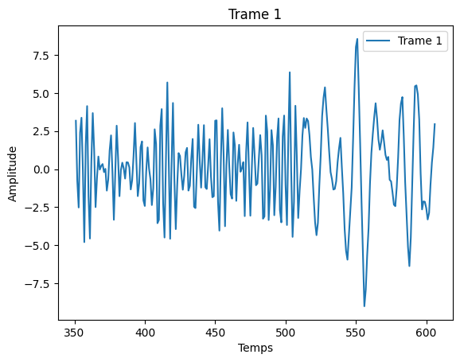

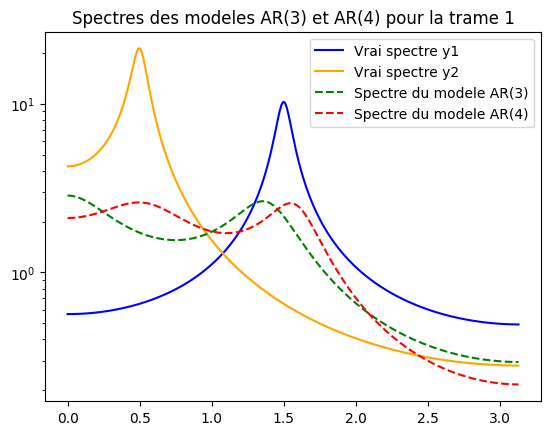

```python
# Calcul des coefficients des modèles AR d'ordre 3 (et 4) pour chaque trame à partir de la donnée 1 sur m1 points

# Affichage de la trame (sous-série)
plt.plot(t[m2:m1+m2],y[m2:m1+m2],label='Trame 1')
plt.xlabel('Temps')
plt.ylabel('Amplitude')
plt.legend()
plt.title('Trame 1')
plt.show()

# Calcul de l'autocorrélation
y1 = y[m2:m1+m2]
y2 = np.roll(y1, 1)
y3 = np.roll(y1, 2)
y4 = np.roll(y1, 3)
y5 = np.roll(y1, 4)
A = [y1, y2, y3, y4, y5]

# Calcul des coefficients par Yule-Walker
D = np.zeros((5,5))
for i in range(5):
    for j in range(5):
        D[i][j] = np.cov(A[i],A[j])[0][1]

H = - np.linalg.inv(D[0:3,0:3]) @ D[0,1:4] # Ordre 3 (@ = produit matriciel)
E = - np.linalg.inv(D[0:4,0:4]) @ D[0,1:5] # Ordre 4

H1 = [1,*H]
E1 = [1,*E]

# Calcul des spectres
f,mag = spectre(H1,E1)

plt.semilogy(f,mag11,'-b',label='Vrai spectre y1')
plt.semilogy(f,mag12,'orange',label='Vrai spectre y2')
plt.semilogy(f,np.abs(mag[0]),'--g',label='Spectre du modele AR(3)')
plt.semilogy(f,np.abs(mag[1]),'--r',label='Spectre du modele AR(4)')

plt.legend()
plt.title('Spectres des modeles AR(3) et AR(4) pour la trame 1')
plt.show()
```

Dans ce cas, on voit que la superposition entre le modèle théorique et les estimations locales est beaucoup moins bonne.

**Calcul des coefficients des modèles AR d'ordre 3 et 4 à partir de la donnée m2+m1 sur m1 données :**

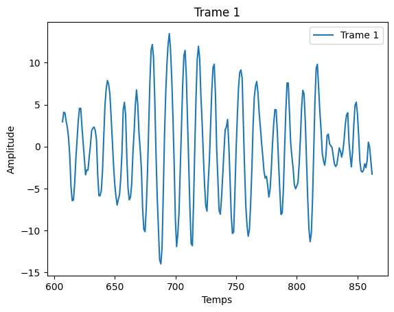

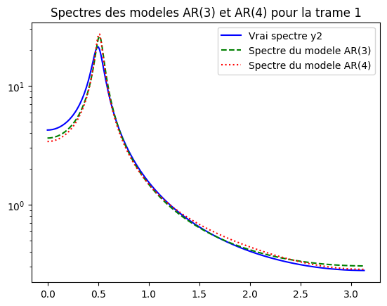

```python
# Calcul des coefficients des modèles AR d'ordre 3 (et 4) pour chaque trame à partir de la donnée 1 sur m1 points

# Affichage de la trame (sous-série)
plt.plot(t[m2+m1:2*m1+m2],y[m2+m1:2*m1+m2],label='Trame 1')
plt.xlabel('Temps')
plt.ylabel('Amplitude')
plt.legend()
plt.title('Trame 1')
plt.show()

# Calcul de l'autocorrélation
y1 = y[m2+m1:2*m1+m2]
y2 = np.roll(y1, 1)
y3 = np.roll(y1, 2)
y4 = np.roll(y1, 3)
y5 = np.roll(y1, 4)
A = [y1, y2, y3, y4, y5]

# Calcul des coefficients par Yule-Walker
D = np.zeros((5,5))
for i in range(5):
    for j in range(5):
        D[i][j] = np.cov(A[i],A[j])[0][1]

H = - np.linalg.inv(D[0:3,0:3]) @ D[0,1:4] # Ordre 3 (@ = produit matriciel)
E = - np.linalg.inv(D[0:4,0:4]) @ D[0,1:5] # Ordre 4

H1 = [1,*H]
E1 = [1,*E]

# Calcul des spectres
f,mag = spectre(H1,E1)

plt.semilogy(f,mag12,'-b',label='Vrai spectre y2')
plt.semilogy(f,np.abs(mag[0]),'--g',label='Spectre du modele AR(3)')
plt.semilogy(f,np.abs(mag[1]),':r',label='Spectre du modele AR(4)')

plt.legend()
plt.title('Spectres des modeles AR(3) et AR(4) pour la trame 1')
plt.show()
```

On voit que l'estimation est très bonne ici !

**Calcul des coefficients des modèles AR d'ordre 3 et 4 à partir de la donnée 2*m2 sur m1 données :**

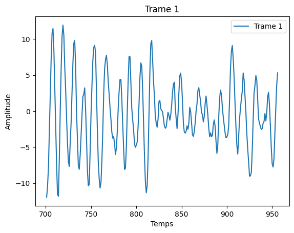

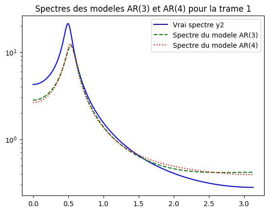

```python
# Calcul des coefficients des modèles AR d'ordre 3 (et 4) pour chaque trame à partir de la donnée 1 sur m1 points

# Affichage de la trame (sous-série)
plt.plot(t[2*m2:m1+2*m2],y[2*m2:m1+2*m2],label='Trame 1')
plt.xlabel('Temps')
plt.ylabel('Amplitude')
plt.legend()
plt.title('Trame 1')
plt.show()

# Calcul de l'autocorrélation
y1 = y[2*m2:m1+2*m2]
y2 = np.roll(y1, 1)
y3 = np.roll(y1, 2)
y4 = np.roll(y1, 3)
y5 = np.roll(y1, 4)
A = [y1, y2, y3, y4, y5]

# Calcul des coefficients par Yule-Walker
D = np.zeros((5,5))
for i in range(5):
    for j in range(5):
        D[i][j] = np.cov(A[i],A[j])[0][1]

H = - np.linalg.inv(D[0:3,0:3]) @ D[0,1:4] # Ordre 3 (@ = produit matriciel)
E = - np.linalg.inv(D[0:4,0:4]) @ D[0,1:5] # Ordre 4

H1 = [1,*H]
E1 = [1,*E]

# Calcul des spectres
f,mag = spectre(H1,E1)

plt.semilogy(f,mag12,'-b',label='Vrai spectre y2')
plt.semilogy(f,np.abs(mag[0]),'--g',label='Spectre du modele AR(3)')
plt.semilogy(f,np.abs(mag[1]),':r',label='Spectre du modele AR(4)')

plt.legend()
plt.title('Spectres des modeles AR(3) et AR(4) pour la trame 1')
plt.show()
```

**Calcul des coefficients des modèles AR d'ordre 3 et 4 à partir de la donnée 2*m2+m1 sur m1 données :**

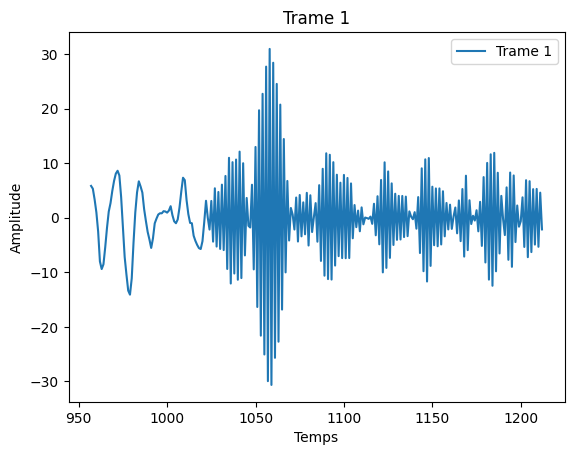

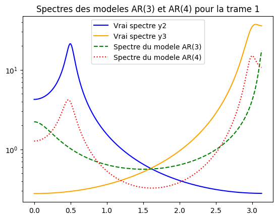

```python
# Calcul des coefficients des modèles AR d'ordre 3 (et 4) pour chaque trame à partir de la donnée 1 sur m1 points

# Affichage de la trame (sous-série)
plt.plot(t[2*m2+m1:2*m1+2*m2],y[2*m2+m1:2*m1+2*m2],label='Trame 1')
plt.xlabel('Temps')
plt.ylabel('Amplitude')
plt.legend()
plt.title('Trame 1')
plt.show()

# Calcul de l'autocorrélation
y1 = y[2*m2+m1:2*m1+2*m2]
y2 = np.roll(y1, 1)
y3 = np.roll(y1, 2)
y4 = np.roll(y1, 3)
y5 = np.roll(y1, 4)
A = [y1, y2, y3, y4, y5]

# Calcul des coefficients par Yule-Walker
D = np.zeros((5,5))
for i in range(5):
    for j in range(5):
        D[i][j] = np.cov(A[i],A[j])[0][1]

H = - np.linalg.inv(D[0:3,0:3]) @ D[0,1:4] # Ordre 3 (@ = produit matriciel)
E = - np.linalg.inv(D[0:4,0:4]) @ D[0,1:5] # Ordre 4

H1 = [1,*H]
E1 = [1,*E]

# Calcul des spectres
f,mag = spectre(H1,E1)

plt.semilogy(f,mag12,'-b',label='Vrai spectre y2')
plt.semilogy(f,mag13,'orange',label='Vrai spectre y3')
plt.semilogy(f,np.abs(mag[0]),'--g',label='Spectre du modele AR(3)')
plt.semilogy(f,np.abs(mag[1]),':r',label='Spectre du modele AR(4)')

plt.legend()
plt.title('Spectres des modeles AR(3) et AR(4) pour la trame 1')
plt.show()
```

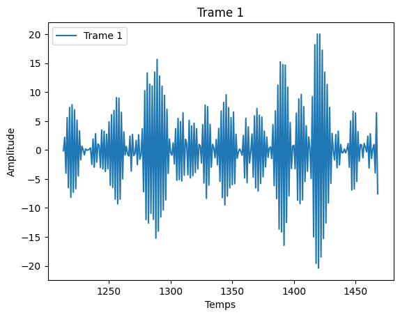

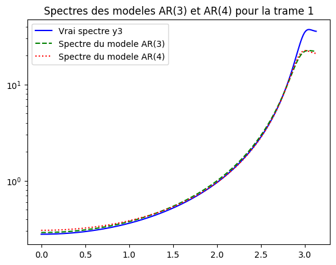

```python
# Calcul des coefficients des modèles AR d'ordre 3 (et 4) pour chaque trame à partir de la donnée 1 sur m1 points

# Affichage de la trame (sous-série)
plt.plot(t[2*m2+2*m1:3*m1+2*m2],y[2*m2+2*m1:3*m1+2*m2],label='Trame 1')
plt.xlabel('Temps')
plt.ylabel('Amplitude')
plt.legend()
plt.title('Trame 1')
plt.show()

# Calcul de l'autocorrélation
y1 = y[2*m2+2*m1:3*m1+2*m2]
y2 = np.roll(y1, 1)
y3 = np.roll(y1, 2)
y4 = np.roll(y1, 3)
y5 = np.roll(y1, 4)
A = [y1, y2, y3, y4, y5]

# Calcul des coefficients par Yule-Walker
D = np.zeros((5,5))
for i in range(5):
    for j in range(5):
        D[i][j] = np.cov(A[i],A[j])[0][1]

H = - np.linalg.inv(D[0:2,0:2]) @ D[0,1:3]
E = - np.linalg.inv(D[0:3,0:3]) @ D[0,1:4]

H1 = [1,*H]
E1 = [1,*E]

# Calcul des spectres
f,mag = spectre(H1,E1)

plt.semilogy(f,mag13,'-b',label='Vrai spectre y3')
plt.semilogy(f,np.abs(mag[0]),'--g',label='Spectre du modele AR(3)')
plt.semilogy(f,np.abs(mag[1]),':r',label='Spectre du modele AR(4)')

plt.legend()
plt.title('Spectres des modeles AR(3) et AR(4) pour la trame 1')
plt.show()
```

Encore une fois, le modèle est très bien estimé.

## Partie II :

**Chargement de la donnée de parole dans y et visualisation de la donnée de parole :**

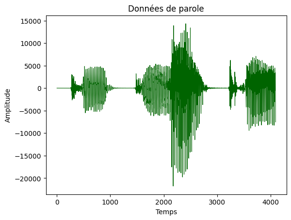

```python
from scipy.io import loadmat
import sounddevice as sd
import scipy.signal as sig

DataParole = loadmat('2_ParoleEtModeleAR/DataParole.mat')
DataParole = DataParole['DataParole']
# wait = input("Ajuster le volume - Puis Appuyer sur une touche du clavier pour continuer.")
wait = 1
sd.play(DataParole, 8192) # son emis via haut parleur externe

# Visualisation de la parole
z = DataParole
plt.plot(z,color='darkgreen',linewidth=0.8)
plt.title('Données de parole')
plt.xlabel('Temps')
plt.ylabel('Amplitude')
plt.show()
```

**Analyse par trames (fenetres) sur y :**

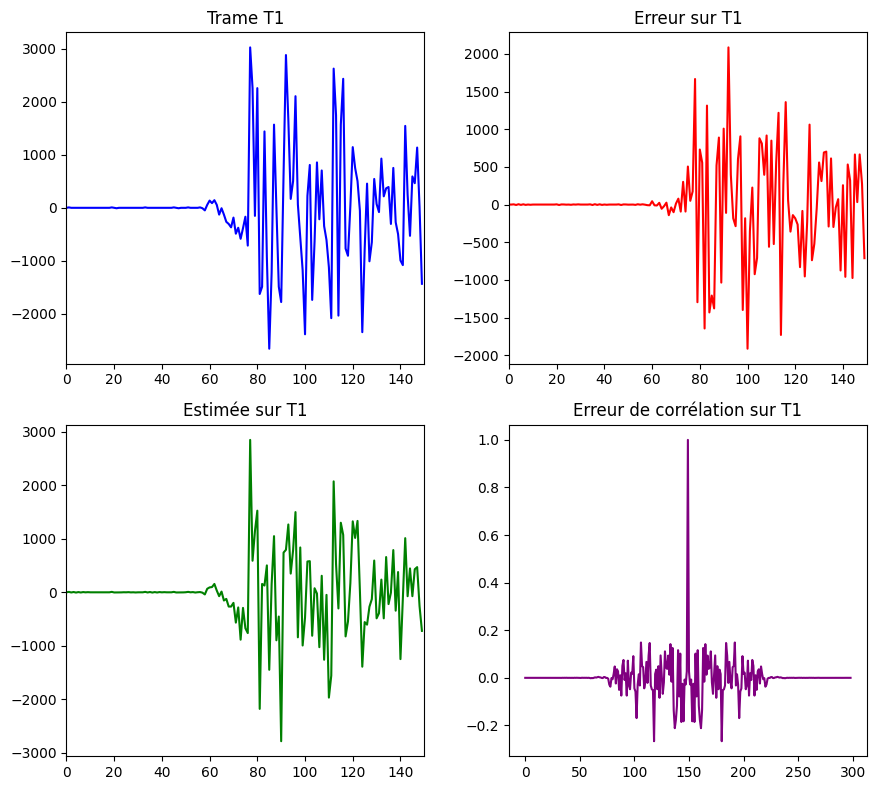

```python
import librosa

# Paramètres d'analyse :
n1 = 200 # Début de la trame à analyser
n2 = len(z) # Fin de la trame à analyser

y = z[n1:n2]

m = 150 # Longueur de chaque trame
nbTrames = int((n2-n1+1)/m) # Nombre de trames
ordreAR = 8 # Ordre du modèle AR

y1 = y[:m]
y1 = np.squeeze(y1)

# Calcul des coefficients AR
y1 = np.asarray(y1, dtype=np.float32)
coeffsAR1 = librosa.lpc(y1, order=ordreAR)

# Calcul de l'estimée (sur une seule courbe)
yf1 = np.convolve(y1, coeffsAR1, mode='full')[:len(y1)]

# Calcul de l'erreur de corrélation
residuel = y1 - yf1[:len(y1)]
residuel = np.transpose(residuel)

# Calcul de l'erreur de corrélation
correlation = sig.correlate(yf1, yf1, mode='full')
correlation = correlation / np.max(correlation)


# Affichage de la trame T1, de l'erreur sur T1, de l'estimée sur T1 et de la erreur de corrélation sur T1 (ATTENTION : sur le matlab, les graphes estimée et erreur sont inversés...)
plt.figure(figsize=(9,8))
plt.subplot(2,2,1)
plt.plot(y1, color='blue')
plt.xlim(0, m)
plt.title('Trame T1')
plt.subplot(2,2,2)
plt.plot(residuel, color='red')
plt.xlim(0, m)
plt.title('Erreur sur T1')
plt.subplot(2,2,3)
plt.plot(yf1, color='green')
plt.xlim(0, m)
plt.title('Estimée sur T1')
plt.subplot(2,2,4)
plt.plot(correlation, color='purple')
plt.title('Erreur de corrélation sur T1')
plt.tight_layout()
plt.show()
```

Explications :

*En gros*, tous ces graphiques permettent de visualiser de analyser la perf de l'estimation de la série temporelle et la nature des erreurs de prédiction.

Sythèses (par BBG et erreur-residuelle) :

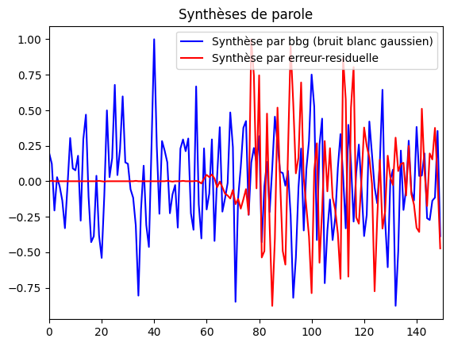

```python
synth2 = sig.lfilter([1], coeffsAR1, np.random.randn(len(y1)))
synth3 = sig.lfilter([1], coeffsAR1, yf1)

plt.plot(synth2/max(abs(synth2)), color='blue', label='Synthèse par bbg (bruit blanc gaussien)')
plt.xlim(0, m)
plt.plot(synth3/max(abs(synth3)), color='red', label='Synthèse par erreur-residuelle')
plt.xlim(0, m)
plt.legend()
plt.title('Synthèses de parole')
plt.show()
```

Explications :

- **Synthèse par Bruit Blanc Gaussien :** Utilise des coefficients AR pour filtrer un bruit blanc afin de générer un signal aux caractéristiques similaires à l'original.
- **Erreur résiduelle :** Utilise les résidus de l'estimation pour générer un signal aux caractéristiques similaires à l'original en éliminant les erreurs de prédiction.

**Analyse et synthèse de la parole sur l'ensemble des trames :**

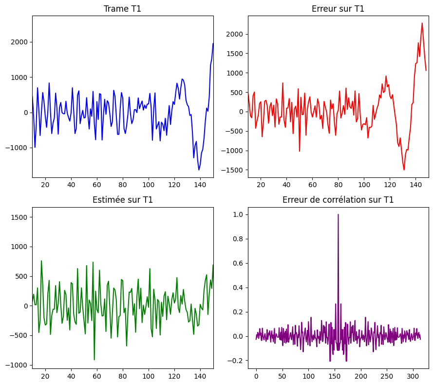

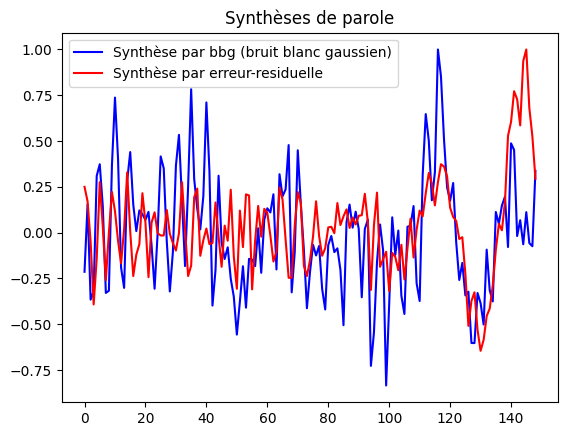

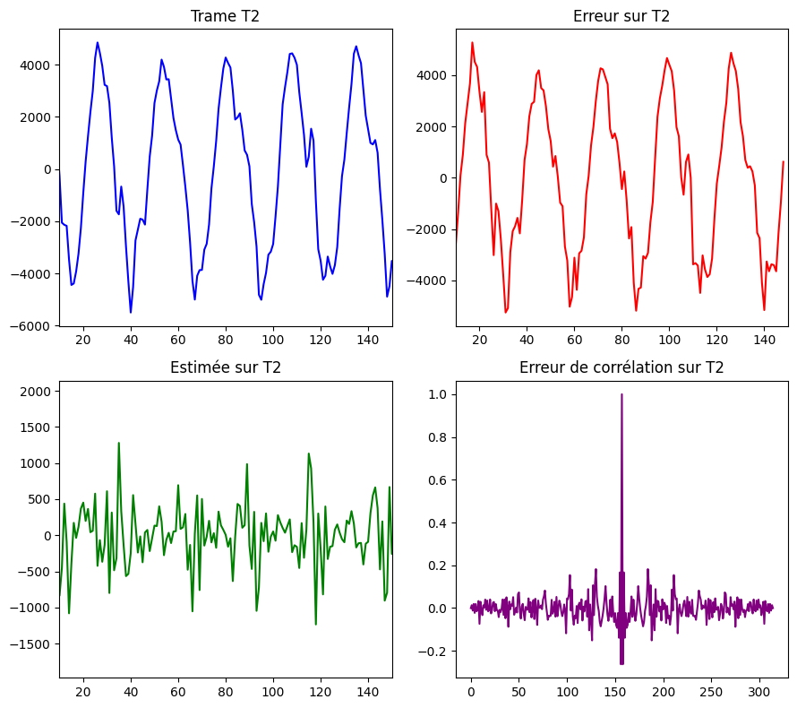

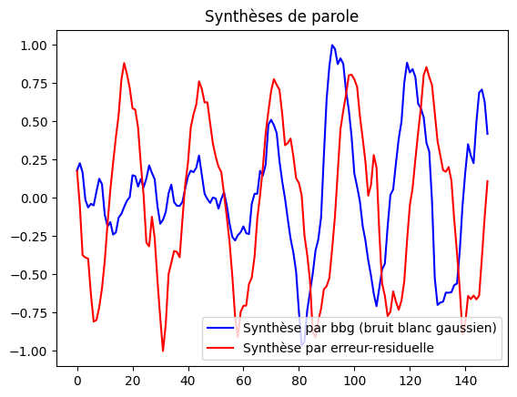

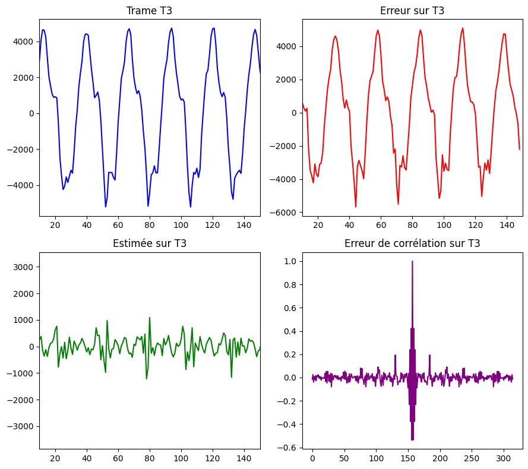

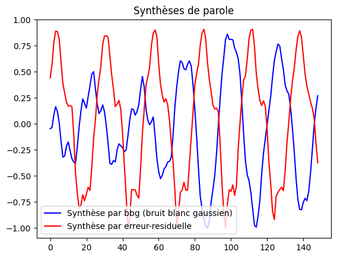

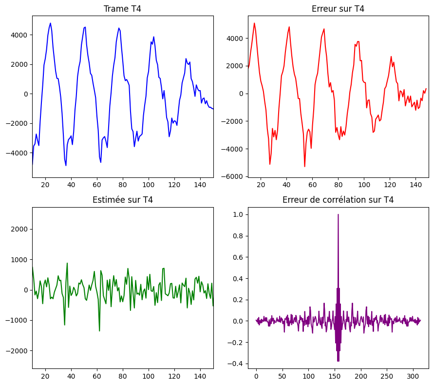

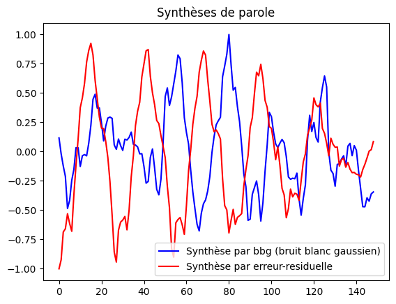

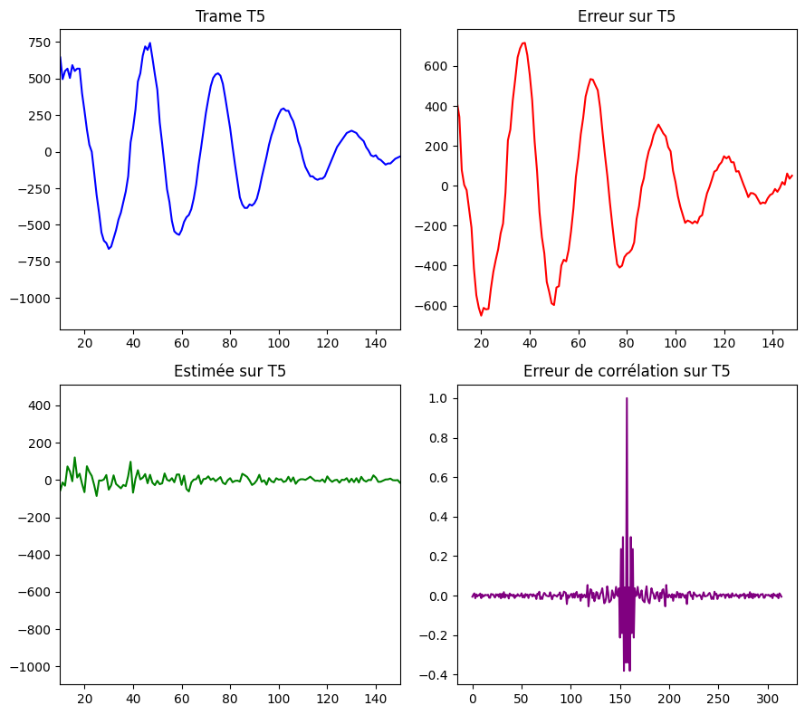

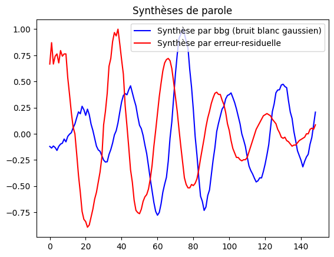

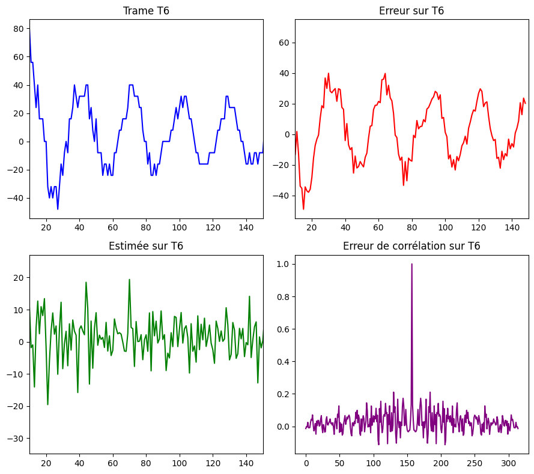

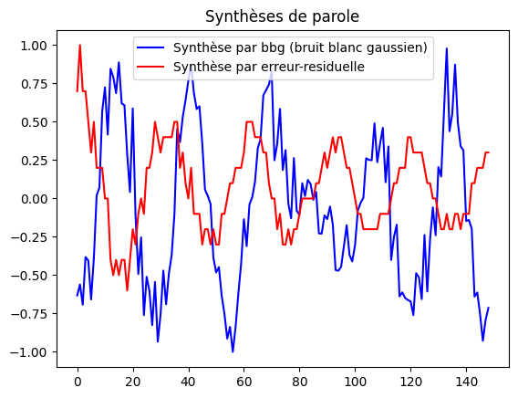

[8 more figures not shown]

```python
nbTramesAffichees = 10 # Doit être inférieur à nbTrames
m1 = ordreAR+1

Synth2 = np.array([])
Synth3 = np.array([])

for k in range(1,nbTrames-1):
    y2 = y[k*m-m1+1:(k+1)*m]
    y2 = np.squeeze(y2)

    # Calcul des coefficients AR
    y2 = np.asarray(y2, dtype=np.float32)
    coeffsAR2 = librosa.lpc(y2, order=ordreAR)

    # Calcul de l'estimée (sur une seule courbe)
    yf2 = np.convolve(y2, coeffsAR2, mode='full')[:len(y2)]

    # Calcul de l'erreur de corrélation
    residuel2 = y2[m1:m1+m-1] - yf2[m1:m1+m-1]
    residuel2 = np.transpose(residuel2)
    residuel = np.concatenate((residuel, residuel2))

    # Calcul de l'erreur de corrélation
    correlation = sig.correlate(yf2, yf2, mode='full')
    correlation = correlation / np.max(correlation) # Normalisation

    # Synthèses
    synth2 = sig.lfilter([1], coeffsAR2, np.random.randn(len(y2)))[m1:m1+m-1]
    synth3 = sig.lfilter([1], coeffsAR2, yf2)[m1:m1+m-1]
    Synth2 = np.concatenate((Synth2, synth2))
    Synth3 = np.concatenate((Synth3, synth3))

    if k <= nbTramesAffichees:
        x_min = 10 # Début de la trame à afficher (pour éviter les valeurs aberrantes du début)

        plt.figure(figsize=(9,8))
        plt.subplot(2,2,1)
        plt.plot(y2, color='blue')
        plt.xlim(x_min, m)
        plt.title('Trame T' + str(k))
        plt.subplot(2,2,2)
        plt.plot(residuel2, color='red')
        plt.xlim(x_min, m)
        plt.title('Erreur sur T' + str(k))
        plt.subplot(2,2,3)
        plt.plot(yf2, color='green')
        plt.xlim(x_min, m)
        plt.title('Estimée sur T' + str(k))
        plt.subplot(2,2,4)
        plt.plot(correlation, color='purple')
        plt.title('Erreur de corrélation sur T' + str(k))
        plt.tight_layout()
        plt.show()

        plt.plot(synth2/max(abs(synth2)), color='blue', label='Synthèse par bbg (bruit blanc gaussien)')
        plt.plot(synth3/max(abs(synth3)), color='red', label='Synthèse par erreur-residuelle')
        plt.legend()
        plt.title('Synthèses de parole')
```